# ПРАКТИЧЕСКАЯ РАБОТА №4

## Графики и кластеризация

Цель: составить графики, проанализировать их и провести кластеризацию.

Используем набор данных из Практической работы №3. Необходимо проделать следующие шаги и описать их в отчёте Python:

- Продемонстировать график количества значений категориального атрибута (countplot);
- Отобразить среднее значение атрибутов (barplot);
- Создать график распределения (distplot);
- Реализовать ящик с усами (boxplot);
- Сделать тепловую карту корреляции (heatmap);
- Показать соотношение между атрибутами (piarplot или pairgrid);
- Провести кластеризацию через Kmeans и DBSCAN и предоставить результаты.

Импортируем библиотеки для работы с набором данных **`pandas`** и **`numpy`**, а также библиотеку **`seaborn`** для построения графиков и библиотеку **`matplotlib.pyplot`** с упрощенными графиками.

```python
import pandas as pd
import numpy as np

# библиотека для построения графиков
import seaborn as sns
# библиотека с упрощенными графиками
import matplotlib.pyplot as plot
```

Выгружаем очищенный набор данных из файла предыдущей работы **`vgsales_5_final.csv`**.

```python
df = pd.read_csv("vgsales_5_final.csv")
```

## Шаг 1.

### Продемонстировать график количества значений категориального атрибута (countplot).

**`countplot()`** создаёт график, позволяющий продемонстрировать количество наблюдений в наборе данных в каждой категориальной ячейке с помощью столбцов.

Построим график для категориального признака Platform из набора данных.

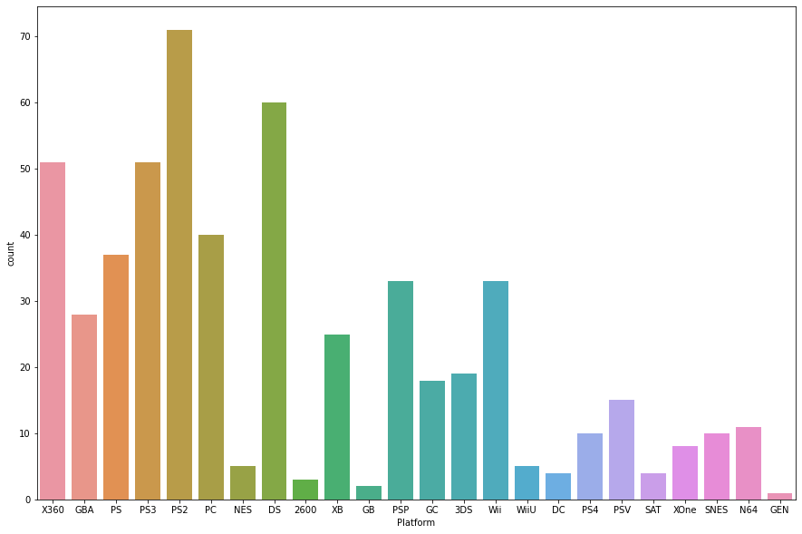

```python
graph = sns.countplot(x="Platform", data = df)
graph.figure.set_figwidth(15)
graph.figure.set_figheight(10)
```

Наименьшее количество наблюдений в наборе данных по категориальному признаку **Platform** имеет **GEN** (по всей видимости под данной аббревиатурой подразумевается Sega Mega Drive, известная в Северной Америке как Sega Genesis). Самой популярной игровой платформой в период проведения исследования (с 1981 по 2016 год) является **PS2** компании Sony. Второй по популярности идёт портативная **DS** компании Nintendo. Трудно сказать по графику, какая платформа идёт третьей по популярности, но, по всей видимости, третье место делят **X360** от компании Microsoft и **PS3** компании Sony.

## Шаг 2.

### Отобразить среднее значение атрибутов (barplot).

**`barplot()`** аггрегирует данные по значениям категориальной переменной и применяет определённую функцию к значениям соответсвующих групп цифровой переменной. По умолчанию эта функция — среднее.

Построим гистограмму распределения мировых продаж по всем игровым платформам.

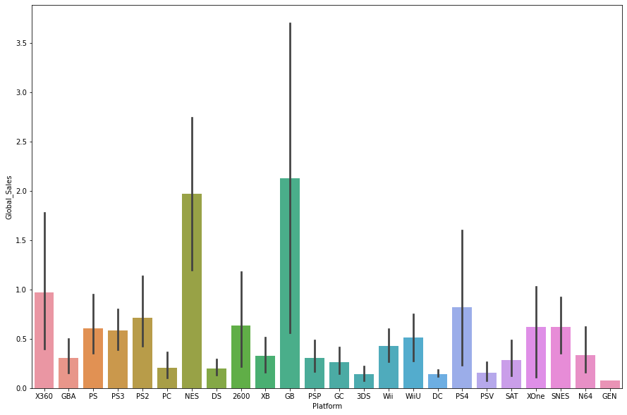

```python
graph = sns.barplot(x=df["Platform"], y=df["Global_Sales"])
graph.figure.set_figwidth(15)
graph.figure.set_figheight(10)
```

В среднем наибольшее количество мировых продаж видеоигр приходится на **GB** (GameBoy), второй идёт **NES** (Nintendo Entertaintment System), третьей **X360**. Плафтормой с наименьшими продажами является **GEN** (Sega Mega Drive - Sega Genesis).

## Шаг 3.

### Создать график распределения (distplot).

**`displot()`** - эта функция предоставляет доступ к нескольким подходам для визуализации одномерного или двумерного распределения данных, включая подмножества данных, определенные с помощью семантического отображения и фасетирования по нескольким подзаголовкам. Параметр вид выбирает подход для использования:

**`histplot()`** (with kind="hist"; по умолчанию);

**`kdeplot()`** (with kind="kde");

**`ecdfplot()`** (with kind="ecdf"; только одномерный).

Кроме того, график **`rugplot()`** может быть добавлен к любому типу графика, чтобы показать отдельные наблюдения. Дополнительные аргументы ключевого слова передаются базовой функции, поэтому вам следует обратиться к документации для каждого из них, чтобы понять полный набор опций для создания графиков с помощью этого интерфейса.

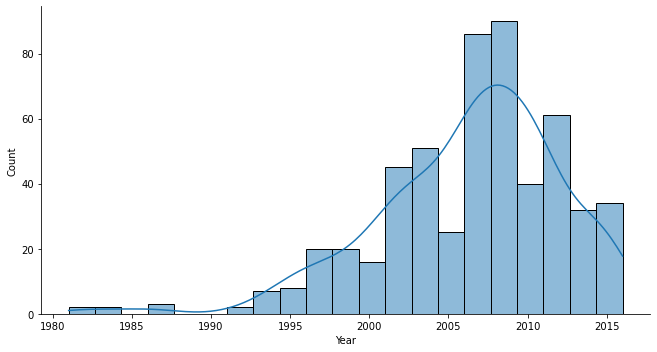

```python
graph = sns.displot(df["Year"], kde = True)
# kind = "kde", kind = True - аргумент, позволяющий построить отдельный график оценки плотности ядра или
# kde рисуется в виде линии поверх гистограммы и часто повторяет форму её форму,
# но дает больше информации о характере распределения.
graph.figure.set_figwidth(10)
graph.figure.set_figheight(5)
```

По графику видно, что начиная с 1990 года количество выпускаемых видеоигр начинает возрастать. Пик выпускаемых видеоигр приходится на период с 2005 по 2010 года. Затем количество выпускаемых видеоигр с 2010 по 2016 год падает.

## Шаг 4.

### Реализовать ящик с усами (boxplot).

**`boxplot()`** — ящик с усами или диаграмма размаха. Такой вид диаграммы в удобной форме показывает медиану (или, если нужно, среднее), нижний и верхний квартили, минимальное и максимальное значение выборки и выбросы. Несколько таких ящиков можно нарисовать бок о бок, чтобы визуально сравнивать одно распределение с другим; их можно располагать как горизонтально, так и вертикально. Расстояния между различными частями ящика позволяют определить степень разброса (дисперсии) и асимметрии данных и выявить выбросы.

Построим диаграмму размаха для мировых продаж видеоигр за всё время наблюдений по различным жанрам.

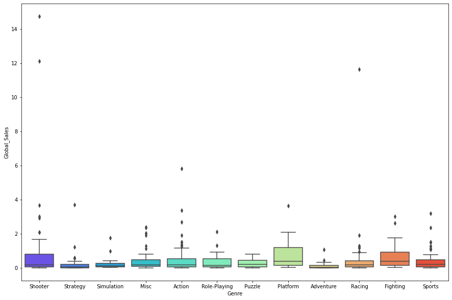

```python
graph = sns.boxplot(x="Genre", y="Global_Sales",data = df,palette='rainbow')
graph.figure.set_figwidth(15)
graph.figure.set_figheight(10)
```

## Шаг 5.

### Сделать тепловую карту корреляции (heatmap).

Тепловая карта (**`heatmap()`**) - это метод визуализации данных, который показывает величину явления в виде цвета в двух измерениях. Изменение цвета может быть вызвано оттенком или интенсивностью, что дает читателю очевидные визуальные подсказки о том, как явление группируется или изменяется в пространстве.

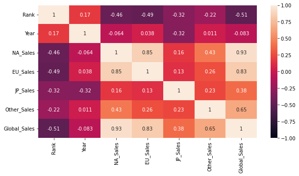

```python
MyHeatMap = sns.heatmap(df.corr(), vmin=-1, vmax=1, annot=True) #аргумент annot=True отображает коэффициент корреляции
MyHeatMap.figure.set_figwidth(10)
MyHeatMap.figure.set_figheight(5)
```

## Шаг 6.

### Показать соотношение между атрибутами (piarplot или pairgrid).

**`pairplot()`** - построение попарных взаимосвязей в наборе данных.

По умолчанию эта функция создаст сетку осей таким образом, что каждая числовая переменная в данных будет разделена по осям y в одной строке и по осям x в одном столбце. Диагональные графики обрабатываются по-разному: строится одномерный график распределения, показывающий предельное распределение данных в каждом столбце.

Также можно отобразить подмножество переменных или отобразить различные переменные в строках и столбцах.

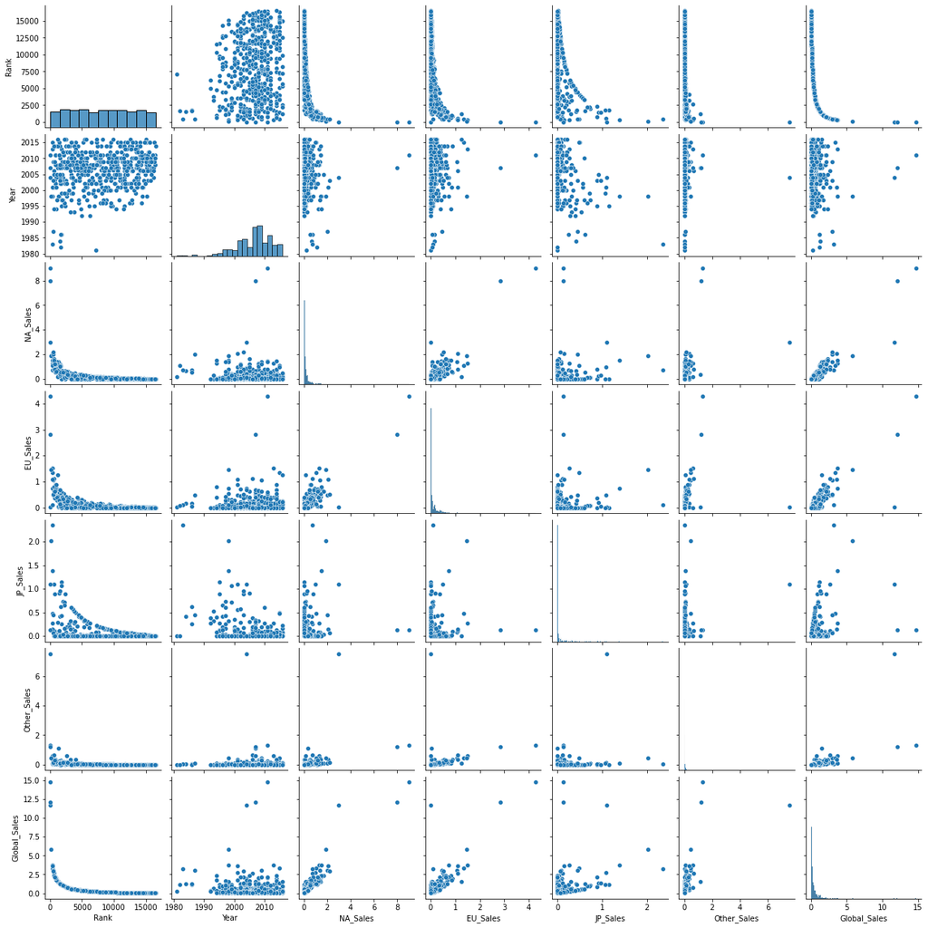

```python
graph = sns.pairplot(df)
```

**`PairGrid()`** - сетка подзаголовков для построения попарных взаимосвязей в наборе данных.

Этот объект сопоставляет каждую переменную в наборе данных со столбцом и строкой в сетке из нескольких осей. Различные функции построения графиков на уровне возрастов могут быть использованы для построения двумерных графиков в верхнем и нижнем треугольниках, а предельное распределение каждой переменной может быть показано по диагонали.

Несколько различных общих пилотов могут быть сгенерированы в одной строке с помощью **`pairplot()`**. Использовать PairGrid лучше в случае, когда нужна большая гибкость в визуализации и построении графиков.

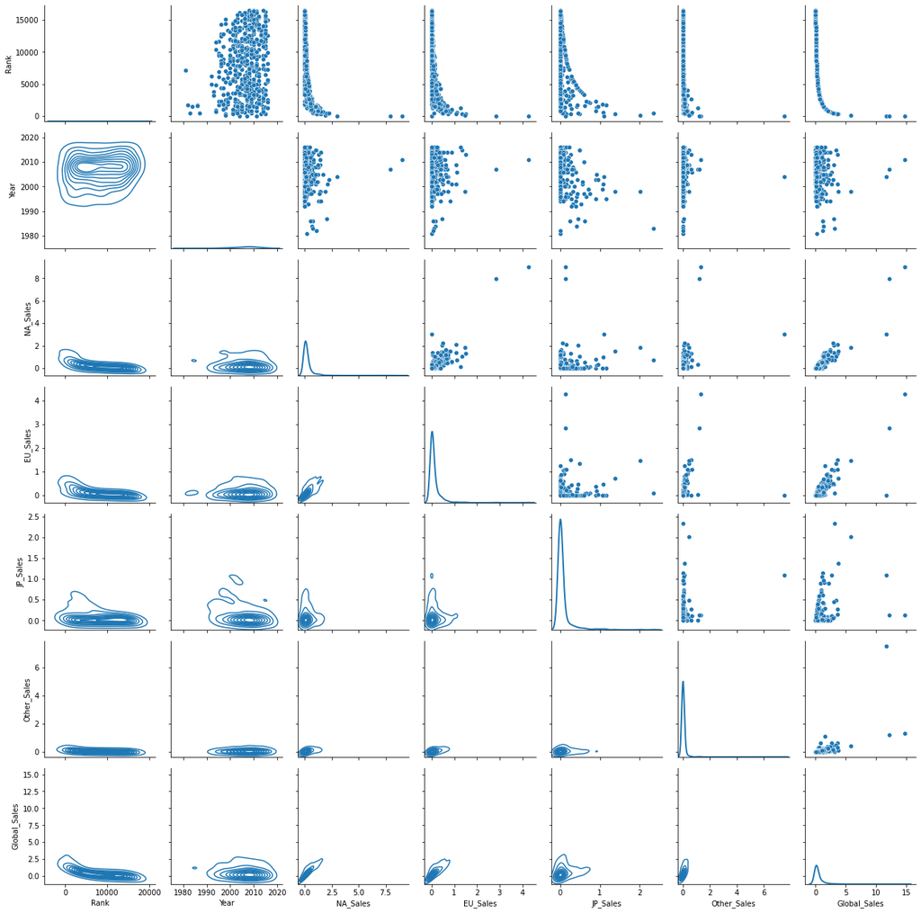

```python
graph = sns.PairGrid(df)
graph = graph.map_upper(sns.scatterplot)
graph = graph.map_lower(sns.kdeplot)
graph = graph.map_diag(sns.kdeplot, lw = 2)
```

## Шаг 7.

### Провести кластеризацию через Kmeans и DBSCAN и предоставить результаты.

**Кластеризация** — задача группировки множества объектов на подмножества (кластеры) таким образом, чтобы объекты из одного кластера были более похожи друг на друга, чем на объекты из других кластеров по какому-либо критерию.

Задача кластеризации относится к классу задач обучения без учителя.

```python
df_mini = df[["NA_Sales","EU_Sales","JP_Sales"]][::50]
df_mini
```

|  | NA_Sales | EU_Sales | JP_Sales |
| --- | --- | --- | --- |
| 0 | 0.05 | 0.00 | 0.00 |
| 50 | 0.00 | 0.00 | 0.35 |
| 100 | 0.35 | 0.03 | 0.00 |
| 150 | 0.00 | 0.00 | 0.03 |
| 200 | 0.00 | 0.00 | 0.01 |
| 250 | 0.28 | 0.03 | 0.00 |
| 300 | 0.21 | 0.05 | 0.00 |
| 350 | 0.08 | 0.03 | 0.17 |
| 400 | 0.68 | 0.43 | 0.29 |
| 450 | 0.00 | 0.00 | 0.19 |
| 500 | 0.32 | 0.34 | 0.00 |

```python
#Кластеризация

from sklearn.cluster import KMeans

model = KMeans(n_clusters=3)

model.fit(df_mini)

all_predictions = model.predict(df_mini)

df_mini["KMeans"] = all_predictions

df_mini
```

|  | NA_Sales | EU_Sales | JP_Sales | KMeans |
| --- | --- | --- | --- | --- |
| 0 | 0.05 | 0.00 | 0.00 | 0 |
| 50 | 0.00 | 0.00 | 0.35 | 0 |
| 100 | 0.35 | 0.03 | 0.00 | 2 |
| 150 | 0.00 | 0.00 | 0.03 | 0 |
| 200 | 0.00 | 0.00 | 0.01 | 0 |
| 250 | 0.28 | 0.03 | 0.00 | 2 |
| 300 | 0.21 | 0.05 | 0.00 | 2 |
| 350 | 0.08 | 0.03 | 0.17 | 0 |
| 400 | 0.68 | 0.43 | 0.29 | 1 |
| 450 | 0.00 | 0.00 | 0.19 | 0 |
| 500 | 0.32 | 0.34 | 0.00 | 2 |

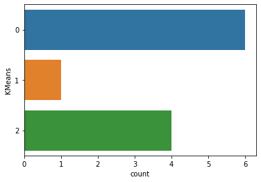

```python
sns.countplot(data = df_mini, y = "KMeans")
```

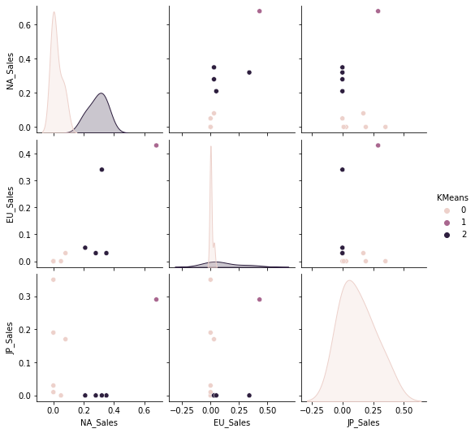

```python
sns.pairplot(df_mini,hue="KMeans")
```

```python
#Переназначение набора данных без столбца предсказаний KMeans

df_mini = df[["NA_Sales","EU_Sales","JP_Sales"]][::1]
df_mini
```

|  | NA_Sales | EU_Sales | JP_Sales |
| --- | --- | --- | --- |
| 0 | 0.05 | 0.00 | 0.00 |
| 1 | 0.08 | 0.03 | 0.00 |
| 2 | 0.08 | 0.04 | 0.00 |
| 3 | 0.12 | 0.08 | 0.74 |
| 4 | 0.00 | 0.12 | 0.00 |
| ... | ... | ... | ... |
| 539 | 0.00 | 0.00 | 0.13 |
| 540 | 0.02 | 0.01 | 0.00 |
| 541 | 0.09 | 0.07 | 0.00 |
| 542 | 0.33 | 0.00 | 0.00 |
| 543 | 0.00 | 0.00 | 0.07 |

544 rows × 3 columns

```python
#DBSCAN - более продвинутая версия KMeans
from sklearn.cluster import DBSCAN

model = DBSCAN()

model.fit(df_mini)

df_mini["DBSCAN"] = model.labels_

df_mini
```

|  | NA_Sales | EU_Sales | JP_Sales | DBSCAN |
| --- | --- | --- | --- | --- |
| 0 | 0.05 | 0.00 | 0.00 | 0 |
| 1 | 0.08 | 0.03 | 0.00 | 0 |
| 2 | 0.08 | 0.04 | 0.00 | 0 |
| 3 | 0.12 | 0.08 | 0.74 | 0 |
| 4 | 0.00 | 0.12 | 0.00 | 0 |
| ... | ... | ... | ... | ... |
| 539 | 0.00 | 0.00 | 0.13 | 0 |
| 540 | 0.02 | 0.01 | 0.00 | 0 |
| 541 | 0.09 | 0.07 | 0.00 | 0 |
| 542 | 0.33 | 0.00 | 0.00 | 0 |
| 543 | 0.00 | 0.00 | 0.07 | 0 |

544 rows × 4 columns

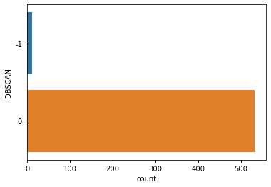

```python
sns.countplot(data = df_mini, y = "DBSCAN")
```

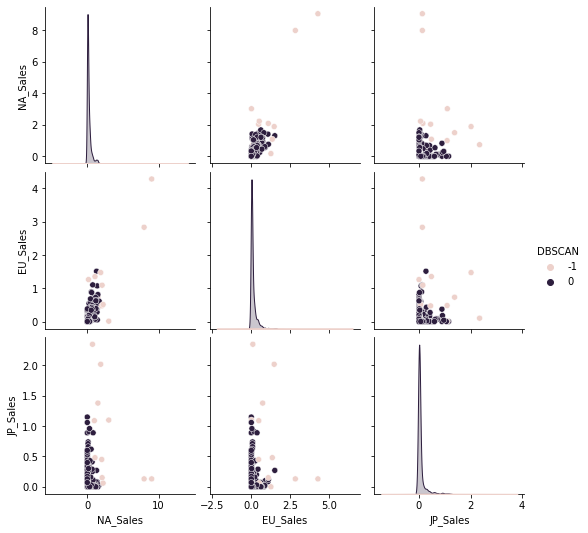

```python
sns.pairplot(df_mini[::1],hue="DBSCAN")
```